# Growth_mort

Carmen

October 31, 2019

# Next step: Consider adding CEIN to the initialization even though there isn’t any in the American River footprint

# This script runs simulations with the most up-to-date functions

# Load functions

#### Create shrub patch

```r
source("functions/shrubclump.R")
```

#### Initialization function

```r
source("functions/initialize.R")
```

#### Height growth functions

```r
source("functions/abcogrowth.R")
source("functions/pipogrowth.R")
```

#### Diameter growth functions

```r
source("functions/abcodia_footprints.R")
source("functions/pipodia_footprints.R")
```

#### Mortality functions

```r
source("functions/abcomort.R")
source("functions/pipomort.R")
```

#### Shrub growth functions

```r
source("functions/abco_shrubgrowth.R")
source("functions/pipo_shrubgrowth.R")
```

#### Simulation function

```r
source("functions/sim.R")
```

#### Iteration function

```r
source("functions/iterate.R")
```

# Define parameters

```r
fire <- "AMRC"
years <- 20
cumsum_2015 <- 0.441
cumsum_2016 <- 0.912
cumsum_2017 <- 1
iterations <- 100
max_shrub_ht_cm <- 250
max_shrub_ht_years <- 15
n_seedlings <- 100
length_m <- 40
height_m <- 40
lambda <- 4
shrub_clumpiness <- 7
```

# Initialize

## Create clumped shrub pattern

```r
shrubclump()
```

## Randomly select seedlings from data and place them on the shrub patch

```r
initialize()
```

## Plot patch with seedlings

```r
pts.sf.pipo.graph <- pts.sf.pipo %>%
  rename("Pine height" = Ht_cm1)
pts.sf.abco.graph <- pts.sf.abco %>%
  rename("Fir height" = Ht_cm1)
```

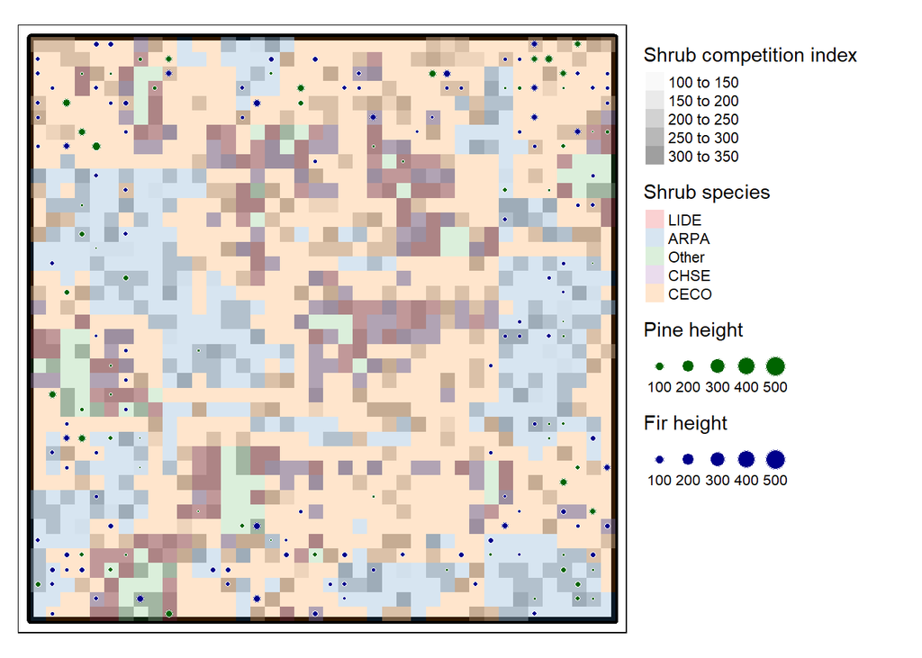

```r
tm_shape(p)+
  tm_borders(col = "black", lwd= 5)+
tm_shape(r)+
  tm_raster(col = "sqrt_shrubarea3", title = "Shrub competition index", palette = "Greys", alpha = .5)+
tm_shape(r)+
  tm_raster(col = "ShrubSpp03", alpha = .2, title = "Shrub species", palette = "Set1")+
  tm_layout(asp=1:1, legend.outside = T)+
tm_shape(pts.sf.pipo.graph)+
  tm_symbols(size = "Pine height", col = "darkgreen", size.max = 500, border.col = "white", border.lwd = .05)+
tm_shape(pts.sf.abco.graph)+
  tm_symbols(size = "Fir height", col = "darkblue", size.max = 500, border.col = "white", border.lwd = .05)
```

# Simulate across years

```r
time <- Sys.time()
suppressMessages(sim(years))
print(paste("One simulation run took", Sys.time()-time, "seconds"))
```

```
## [1] "One simulation run took 7.52770495414734 seconds"
```

# Tests

### Plot # of new emergents each year

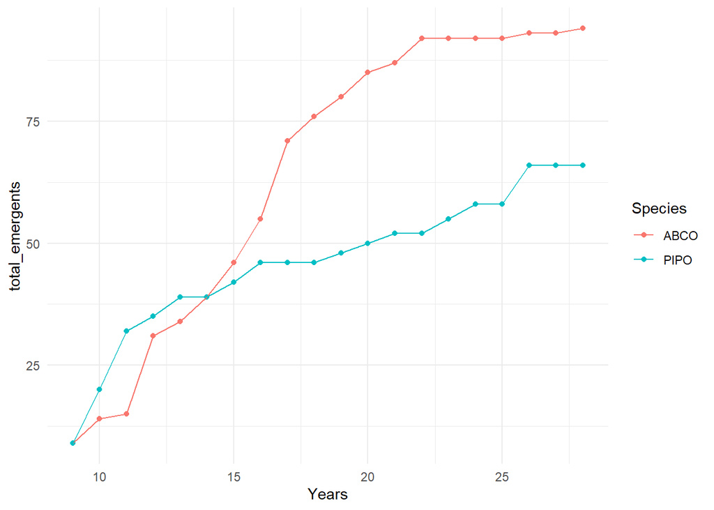

```r
dfsimall %>%
  group_by(Years, Species) %>%
  mutate(emerged = ifelse(
    Ht_cm1>Ht1.3, 1, 0
  )) %>%
  select(Sdlg, Species, ID_withinrep, Ht1.3, Ht_cm1, Years, emerged) %>%
  group_by(Species, ID_withinrep) %>%
  arrange(Years) %>%
  mutate(cumsum_emerge = cumsum(emerged)) %>%
  mutate(new_emerge = ifelse(cumsum_emerge ==1, 1, 0)) %>%
  ungroup() %>%
  group_by(Years, Species) %>%
  summarize(new_emergents = sum(new_emerge)) %>%
  ungroup() %>%
  group_by(Species) %>%
  arrange(Years) %>%
  mutate(total_emergents = cumsum(new_emergents)) %>%
  ggplot(aes(x = Years, y = total_emergents, col = Species))+
  geom_point()+
  geom_line()+
  theme_minimal()
```

### Shrub growth patterns

```r
ht <- ggplot(dfsimall)+
  geom_line(aes(x = Years, y = Ht1.3, col = ShrubSpp03, linetype = Species, group = Sdlg))+
  theme_bw()
```

```r
cov <- ggplot(dfsimall)+
  geom_line(aes(x = Years, y = Cov1.3, col = ShrubSpp03, linetype = Species, group = Sdlg))+
  theme_bw()
```

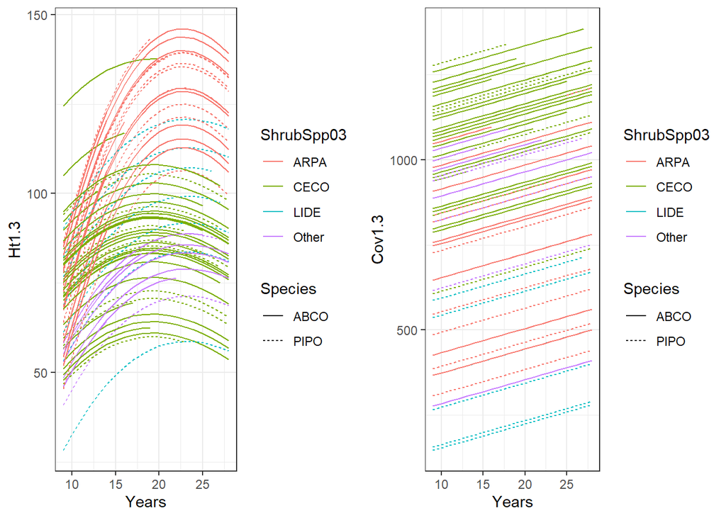

```r
grid.arrange(ht, cov, ncol = 2)
```

### Focal tree dia and ht growth patterns

```r
dia <- ggplot(dfsimall, aes(x = Years, y = dia.cm, col = Species, group = Sdlg))+
  geom_line(alpha = .3)+
  theme_bw()+
  geom_smooth(aes(x = Years, y = dia.cm, col = Species, group = Species))
```

```r
ht <- ggplot(dfsimall, aes(x = Years, y = Ht_cm1, col = Species, group = Sdlg))+
  geom_line(alpha = .3)+
  theme_bw()+
  geom_smooth(aes(x = Years, y = Ht_cm1, col = Species, group = Species))
```

```r
ratio <- ggplot(dfsimall, aes(x = Years, y = dia.cm/Ht_cm1, col = Species, group = Sdlg))+
  geom_line(alpha = .3)+
  theme_bw()+
  geom_smooth(aes(x = Years, y = dia.cm/Ht_cm1, col = Species, group = Species))
```

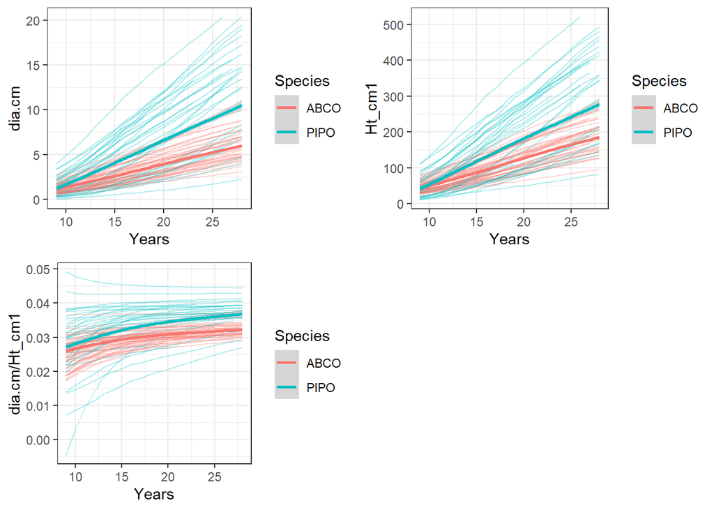

```r
grid.arrange(dia, ht, ratio, ncol = 2)
```

### Diameter and height boxplots

```r
all_dia <- ggplot(dfsimall)+
  geom_boxplot(aes(x = as.factor(Years), y = dia.cm, fill = Species))+
  theme_minimal()+
  xlab("Years")+
  ylab("Diameter (cm)")+
  scale_x_discrete(name = "Years since fire", breaks = c("10", "15", "20", "25"))+
  theme(legend.position="none")
```

```r
strt_dia <- ggplot(dfsimall %>% filter(Years<11))+
  geom_boxplot(aes(x = as.factor(Years), y = dia.cm, fill = Species))+
  theme_minimal()+
  xlab("Years")+
  ylab("Diameter (cm)")+
  ggtitle("Diameter distribution after\nfirst simulation year")
```

```r
all_ht <- ggplot(dfsimall)+
  geom_boxplot(aes(x = as.factor(Years), y = Ht_cm1, fill = Species))+
  theme_minimal()+
  xlab("Years")+
  ylab("Height (cm)")+
  scale_x_discrete(name = "Years since fire", breaks = c("10", "15", "20", "25"))+
  theme(legend.position="none")
```

```r
strt_ht <- ggplot(dfsimall %>% filter(Years<11))+
  geom_boxplot(aes(x = as.factor(Years), y = Ht_cm1, fill = Species))+
  theme_minimal()+
  xlab("Years")+
  ylab("Diameter (cm)")+
  ggtitle("Diameter distribution after\nfirst simulation year")
```

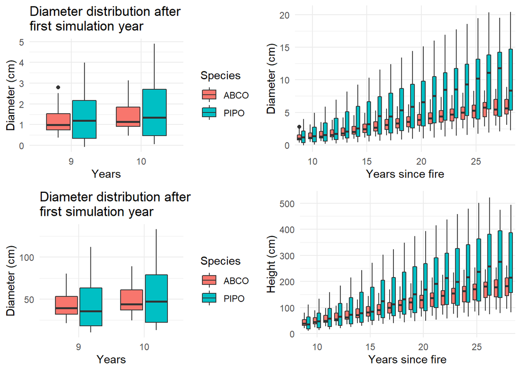

```r
grid.arrange(strt_dia, all_dia, strt_ht, all_ht)
```

## Plot shrub patch spatially

```r
pts.sf.pipo.graph <- pts.sf.pipo %>%
  rename("Pine height (cm)" = Ht_cm1)
pts.sf.abco.graph <- pts.sf.abco %>%
  rename("Fir height (cm)" = Ht_cm1)
```

```
## Note that 12 values of the variable "Pine height (cm)" (the highest being 493.494274992831) are larger than size.max, which is currently set to 300. It is recommended to set size.max to at least 493.494274992831. Another option is to set size.lim = c(0, 300), which truncates the size of the 12 la…
```

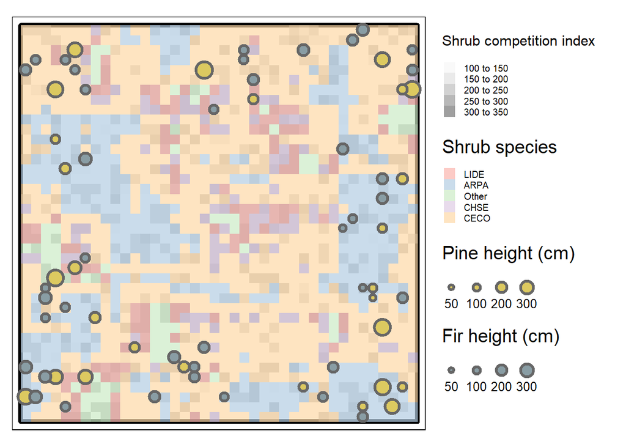

```r
tm_shape(p)+
  tm_borders(col = "black", lwd= 5)+
tm_shape(r)+
  tm_raster(col = "sqrt_shrubarea3", title = "Shrub competition index", palette = "Greys", alpha = .5)+
tm_shape(r)+
  tm_raster(col = "ShrubSpp03", alpha = .7, title = "Shrub species", palette = "Pastel1")+
  tm_layout(asp=1:1, legend.outside = T, legend.title.size = 4, legend.text.size = 2)+
tm_shape(pts.sf.pipo.graph)+
  tm_symbols(size = "Pine height (cm)", col = "#DCC960", size.max = 300, border.lwd = 3)+
tm_shape(pts.sf.abco.graph)+
  tm_symbols(size = "Fir height (cm)", col = "#899DA4", size.max = 300, border.lwd = 3)
```

# Iterate

```r
time <- Sys.time()
iterate(iterations)
```

```
## [1] "Done with 10 iterations in 2.1 minutes"
## [1] "Done with 20 iterations in 3.9 minutes"
## [1] "Done with 30 iterations in 5.6 minutes"
## [1] "Done with 40 iterations in 7.3 minutes"
## [1] "Done with 50 iterations in 9.1 minutes"
## [1] "Done with 60 iterations in 10.9 minutes"
## [1] "Done with 70 iterations in 13.2 minutes"
## [1] "Done with 80 iterations in 15.4 minutes"
## [1] "Done with 90 iterations in 17.2 minutes"
## [1] "Done with 100 iterations in 18.9 minutes"
```

```r
print(paste("That took", round(Sys.time()-time, 1), "minutes"))
```

```
## [1] "That took 18.8 minutes"
```

# Summarize

## Height by year

```r
dfsimallreps_summary <- dfsimallreps %>%
  ungroup() %>%
  mutate(rep = as.factor(paste(rep))) %>%
  group_by(rep, Years, Species) %>%
  mutate(mean_ht_years = mean(Ht_cm1))
```

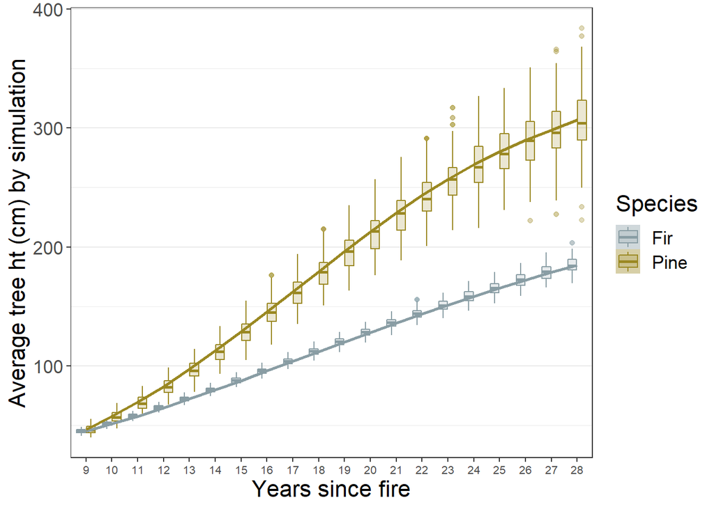

```r
ht <- ggplot(dfsimallreps_summary, aes(x = as.factor(Years), y = mean_ht_years, fill = Species, col = Species))+
  geom_boxplot(alpha = .2, outlier.alpha = .02)+
  geom_smooth(aes(x = as.factor(Years), y = mean_ht_years, group = Species, col = Species), size = 1)+
  xlab("Years since fire")+
  ylab("Average tree ht (cm) by simulation")+
  theme_bw()+
  scale_color_manual(values = c("#899DA4", "#9A8822"), labels = c("Fir", "Pine"))+
  scale_fill_manual(values = c("#899DA4", "#9A8822"), labels = c("Fir", "Pine"))+
  theme(text = element_text(size = 16),
        panel.grid.minor.x = element_blank(),
        panel.grid.major.x = element_blank(),
        axis.text.x = element_text(size = 8))
ht
```

```r
ggsave(file = "../../results/figures/Simulations/sim_100_hts.png", width = 6, height =4, dpi = 400)
```

#### Shrub growth patterns

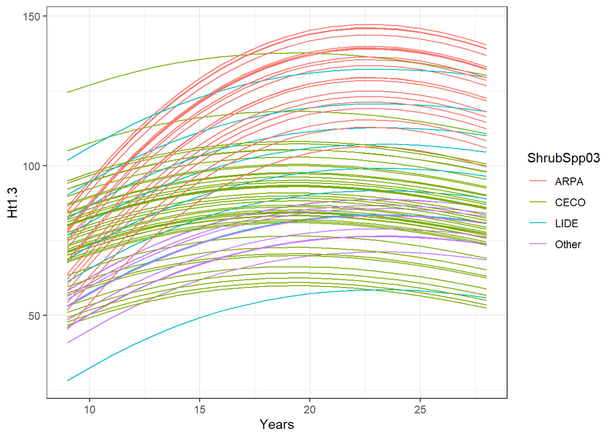

```r
ggplot(dfsimallreps_summary)+
  geom_line(aes(x = Years, y = Ht1.3, col = ShrubSpp03, group = Sdlg))+
  theme_bw()
```

### Diameter growth patterns - FIX THIS FOR PIPO

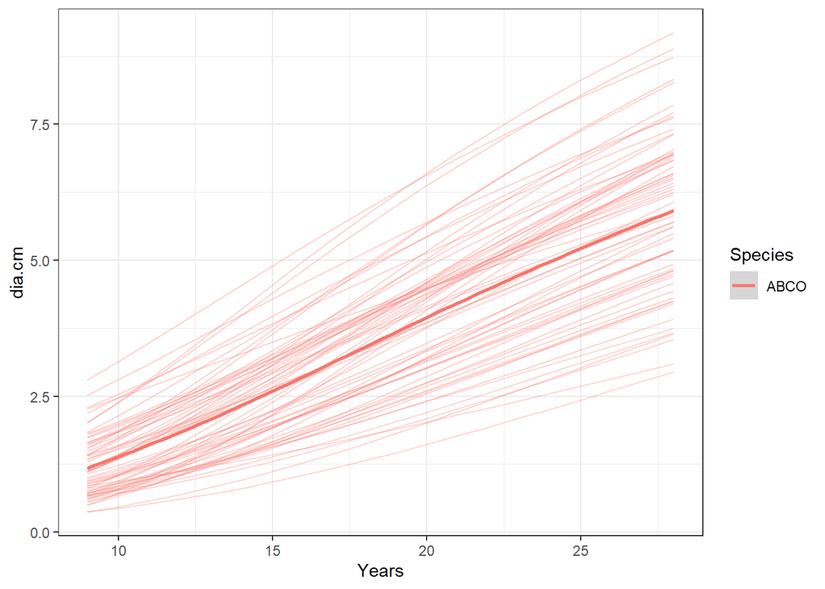

```r
ggplot(dfsimallreps_summary %>% filter(Species == "ABCO"))+
  geom_line(aes(x = Years, y = dia.cm, col = Species, group = Sdlg), alpha = .3)+
  theme_bw()+
  geom_smooth(aes(x = Years, y = dia.cm, col = Species, group = Species))
```

#### For a single tree

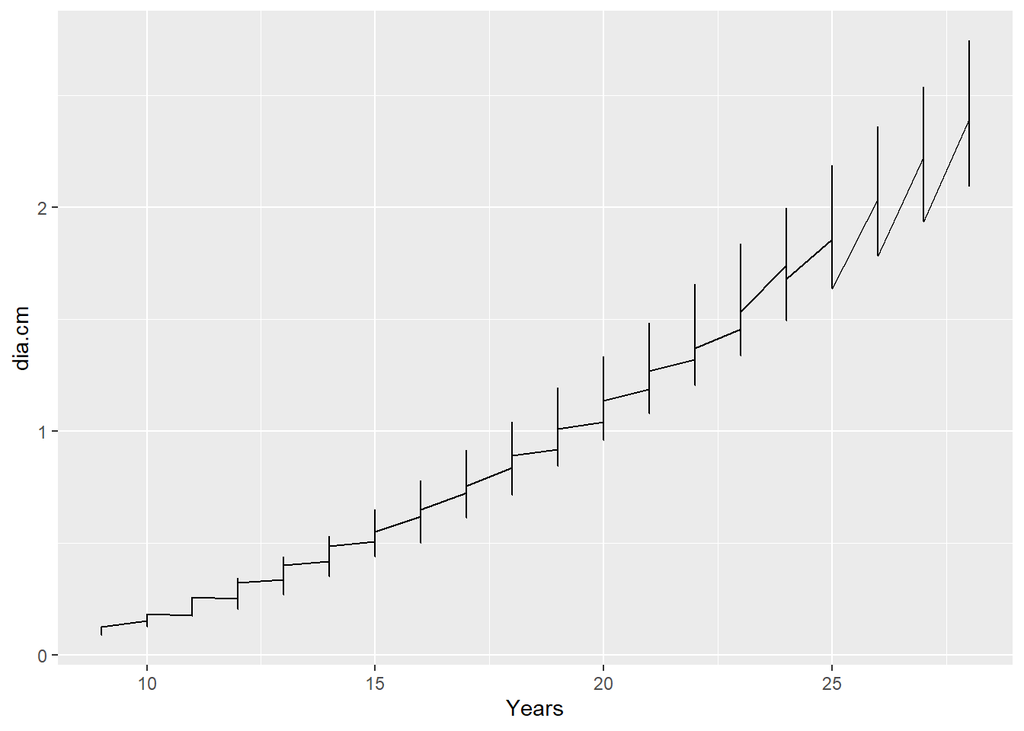

```r
ggplot(dfsimallreps %>% filter(Sdlg == 244))+
  geom_line(aes(x = Years, y = dia.cm))
```

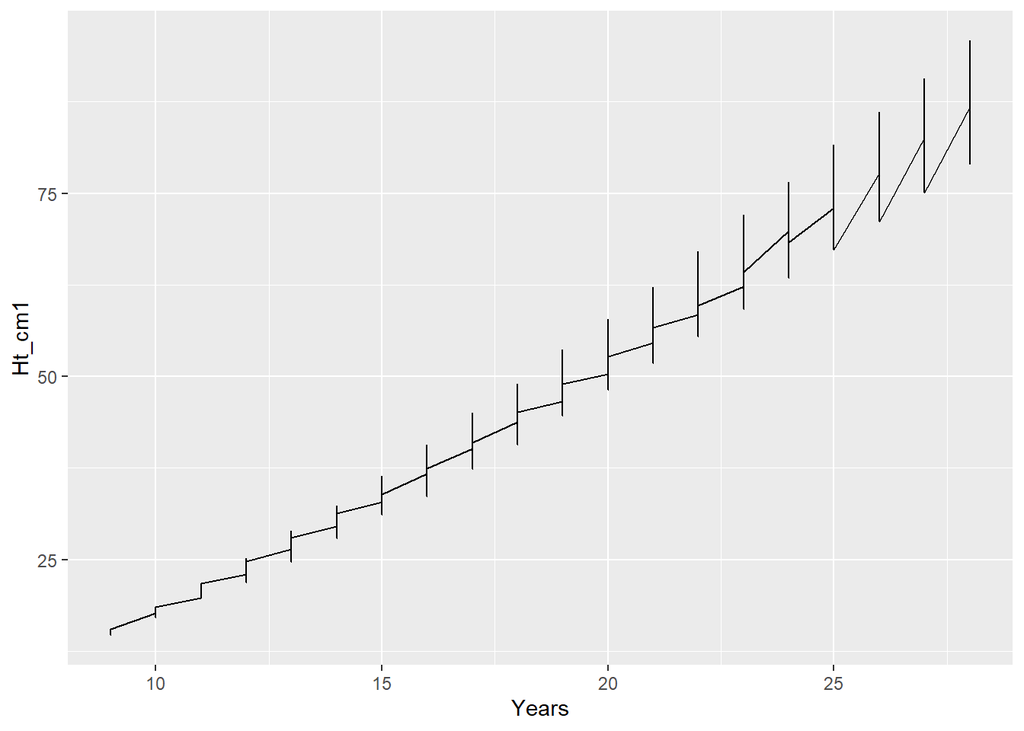

```r
ggplot(dfsimallreps %>% filter(Sdlg == 244))+
  geom_line(aes(x = Years, y = Ht_cm1))
```

#### Plot the relationships between variables inputting the diameter growth equations to compare them to what I saw in the dendro analysis

```r
test <- dfsimallreps %>%
  filter(Years %in% c(19,20)) %>%
  dplyr::select(Sdlg, Species, Ht_cm1, dia.cm, Years, pred_exp, rep, ID_withinrep) %>%
  tbl_df() %>%
  arrange(Sdlg)
test
```

```
## # A tibble: 28,786 x 8
##    Sdlg  Species Ht_cm1 dia.cm Years pred_exp   rep ID_withinrep
##    <chr> <fct>    <dbl>  <dbl> <dbl>    <dbl> <int>        <int>
##  1 104   ABCO      172.   4.87    20   0.0601     1            1
##  2 104   ABCO      172.   4.87    20   0.0601     1           76
##  3 104   ABCO      172.   4.87    20   0.0601     1          189
##  4 104   ABCO      163.   4.57    19   0.0659     1            1
##  5 104   ABCO      163.   4.57    19   0.0659     1           76
##  6 104   ABCO      163.   4.57    19   0.0659     1          189
##  7 104   ABCO      172.   4.87    20   0.0601     2          166
##  8 104   ABCO      163.   4.57    19   0.0659     2          166
##  9 104   ABCO      172.   4.87    20   0.0601     4           21
## 10 104   ABCO      163.   4.57    19   0.0659     4           21
## # ... with 28,776 more rows
```

```r
test <- test %>%
  mutate(ID = paste(Sdlg, rep, ID_withinrep, sep = "-"))
test %>%
  arrange(ID)
```

```
## # A tibble: 28,786 x 9
##    Sdlg  Species Ht_cm1 dia.cm Years pred_exp   rep ID_withinrep ID
##    <chr> <fct>    <dbl>  <dbl> <dbl>    <dbl> <int>        <int> <chr>
##  1 104   ABCO      172.   4.87    20   0.0601     1            1 104-1-1
##  2 104   ABCO      163.   4.57    19   0.0659     1            1 104-1-1
##  3 104   ABCO      172.   4.87    20   0.0601     1          189 104-1-189
##  4 104   ABCO      163.   4.57    19   0.0659     1          189 104-1-189
##  5 104   ABCO      172.   4.87    20   0.0601     1           76 104-1-76
##  6 104   ABCO      163.   4.57    19   0.0659     1           76 104-1-76
##  7 104   ABCO      172.   4.87    20   0.0601    10          131 104-10-131
##  8 104   ABCO      163.   4.57    19   0.0659    10          131 104-10-131
##  9 104   ABCO      172.   4.87    20   0.0601    10          180 104-10-180
## 10 104   ABCO      163.   4.57    19   0.0659    10          180 104-10-180
## # ... with 28,776 more rows
```

```r
test2 <- pivot_wider(test, names_from = "Years", values_from = "dia.cm", id_cols = "ID")
test2 %>%
  arrange(ID)
```

```
## # A tibble: 14,763 x 3
##    ID           `20`  `19`
##    <chr>       <dbl> <dbl>
##  1 104-1-1      4.87  4.57
##  2 104-1-189    4.87  4.57
##  3 104-1-76     4.87  4.57
##  4 104-10-131   4.87  4.57
##  5 104-10-180   4.87  4.57
##  6 104-10-30    4.87  4.57
##  7 104-100-155  4.87  4.57
##  8 104-100-18  NA     4.57
##  9 104-100-49   4.87  4.57
## 10 104-100-82   4.87  4.57
## # ... with 14,753 more rows
```

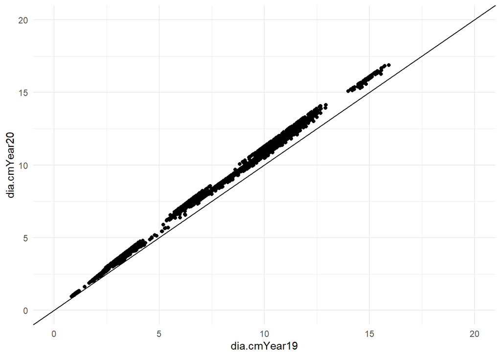

```r
test2 <- test2 %>%
  rename(dia.cmYear19 = `19`, dia.cmYear20 = `20`)

ggplot(test2)+
  geom_point(aes(x = dia.cmYear19, y = dia.cmYear20))+
  geom_abline(aes(slope = 1, intercept = 0))+
  theme_minimal()+
  ylim(0,20)+
  xlim(0,20)
```

### Height growth patterns

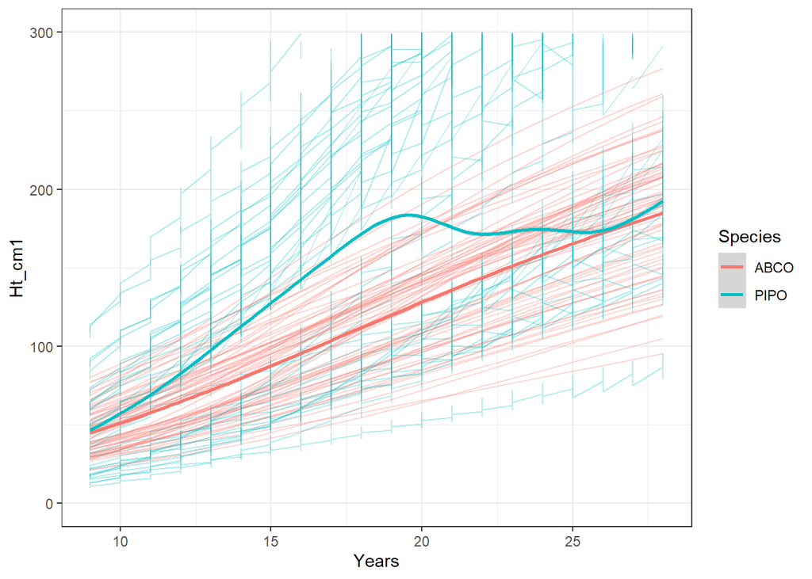

```r
ggplot(dfsimallreps_summary, aes(x = Years, y = Ht_cm1, col = Species, group = Sdlg))+
  geom_line(alpha = .3)+
  theme_bw()+
  geom_smooth(aes(x = Years, y = Ht_cm1, col = Species, group = Species))+
  ylim(0,300)
```

### Diameter::Height growth patterns

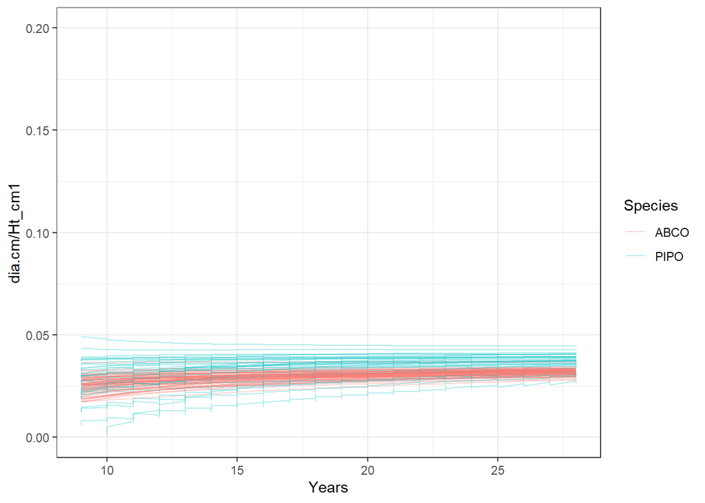

```r
ggplot(dfsimallreps_summary, aes(x = Years, y = dia.cm/Ht_cm1, col = Species, group = Sdlg))+
  geom_line(alpha = .3)+
  theme_bw()+
  ylim(0,.2)
```

### Diameter:height

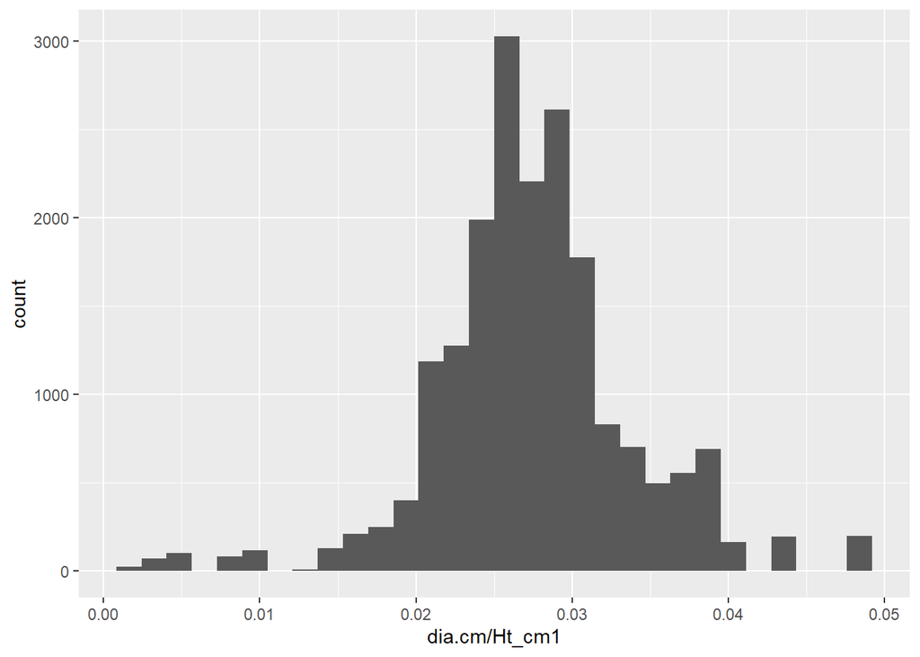

```r
ggplot(dfsimallreps_summary %>% filter(Years==10))+
  geom_histogram(aes(dia.cm/Ht_cm1, bins = 20))
```

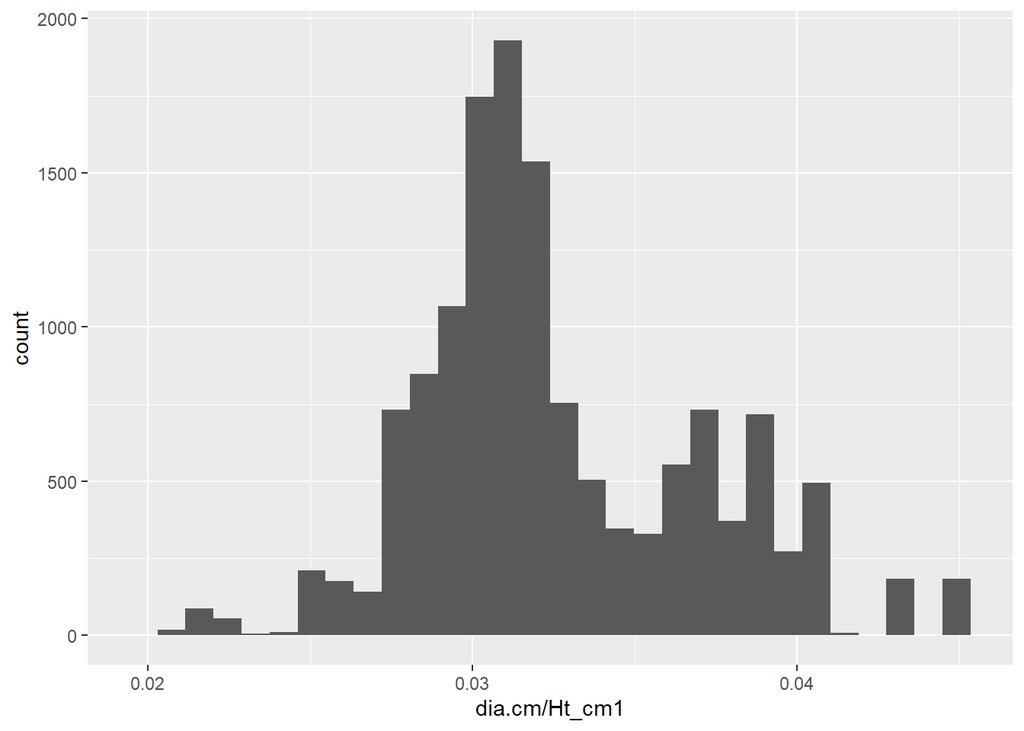

```r
ggplot(dfsimallreps_summary %>% filter(Years==20))+
  geom_histogram(aes(dia.cm/Ht_cm1, bins = 20))
```

### Diameter and height boxplots

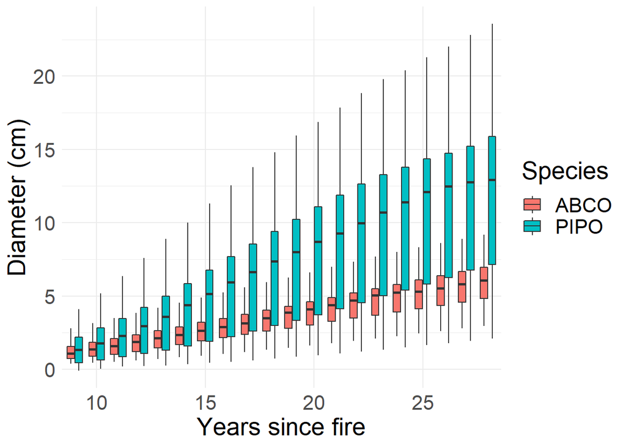

```r
ggplot(dfsimallreps_summary)+
  geom_boxplot(aes(x = as.factor(Years), y = dia.cm, fill = Species))+
  theme_minimal()+
  xlab("Years")+
  ylab("Diameter (cm)")+
  theme(text = element_text(size = 20))+
  scale_x_discrete(name = "Years since fire", breaks = c("10", "15", "20", "25"))
```

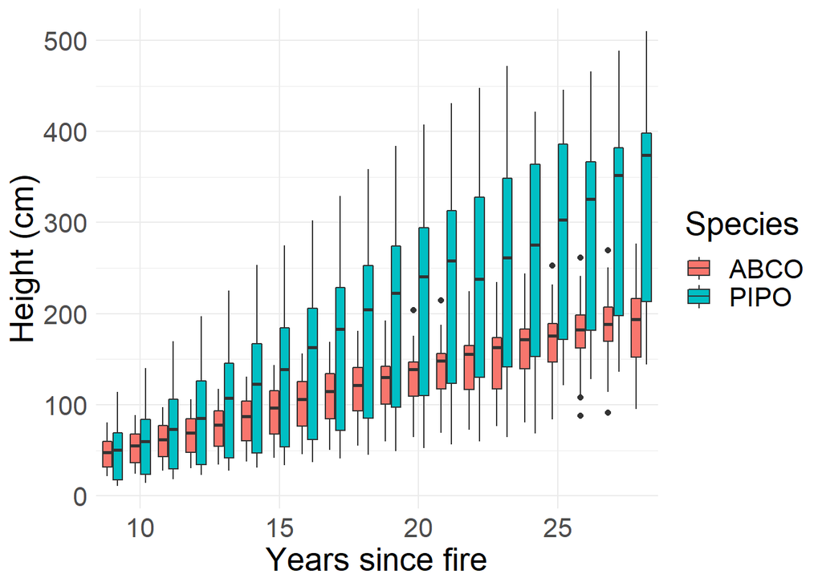

```r
ggplot(dfsimall)+
  geom_boxplot(aes(x = as.factor(Years), y = Ht_cm1, fill = Species))+
  theme_minimal()+
  xlab("Years")+
  ylab("Height (cm)")+
  theme(text = element_text(size = 20))+
  scale_x_discrete(name = "Years since fire", breaks = c("10", "15", "20", "25"))
```

## Counts by year

```r
dfsimallreps_summary <- dfsimallreps %>%
  ungroup() %>%
  group_by(rep, Years, Species) %>%
  mutate(count = n()) %>%
  mutate(count = as.numeric(count))
```

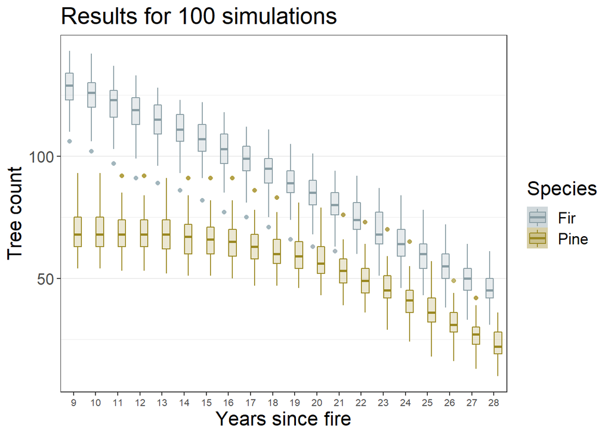

```r
ggplot(dfsimallreps_summary, aes(x = as.factor(Years), y = count, fill = Species, col = Species))+
  geom_boxplot(alpha = .2, outlier.alpha = .02)+
  geom_smooth(aes(x = as.factor(Years), y = count, fill = Species, col = Species), size = 1)+
  ggtitle("Results for 100 simulations")+
  xlab("Years since fire")+
  ylab("Tree count")+
  theme_bw()+
  scale_color_manual(values = c("#899DA4", "#9A8822"), labels = c("Fir", "Pine"))+
  scale_fill_manual(values = c("#899DA4", "#9A8822"), labels = c("Fir", "Pine"))+
  theme(text = element_text(size = 16),
        panel.grid.minor.x = element_blank(),
        panel.grid.major.x = element_blank(),
        axis.text.x = element_text(size = 8))
```

```r
ggsave(file = "../../results/figures/Simulations/sim_100_count.png", width = 6, height = 4, dpi = 400)
```

## Shrub height by year

```r
dfsimallreps_summary <- dfsimallreps %>%
  ungroup() %>%
  group_by(rep, Years, Ht1.3, Cov1.3, ShrubSpp03) %>%
  mutate(mean_shrub_ht = mean(Ht1.3), mean_shrub_cov = mean(Cov1.3))
```

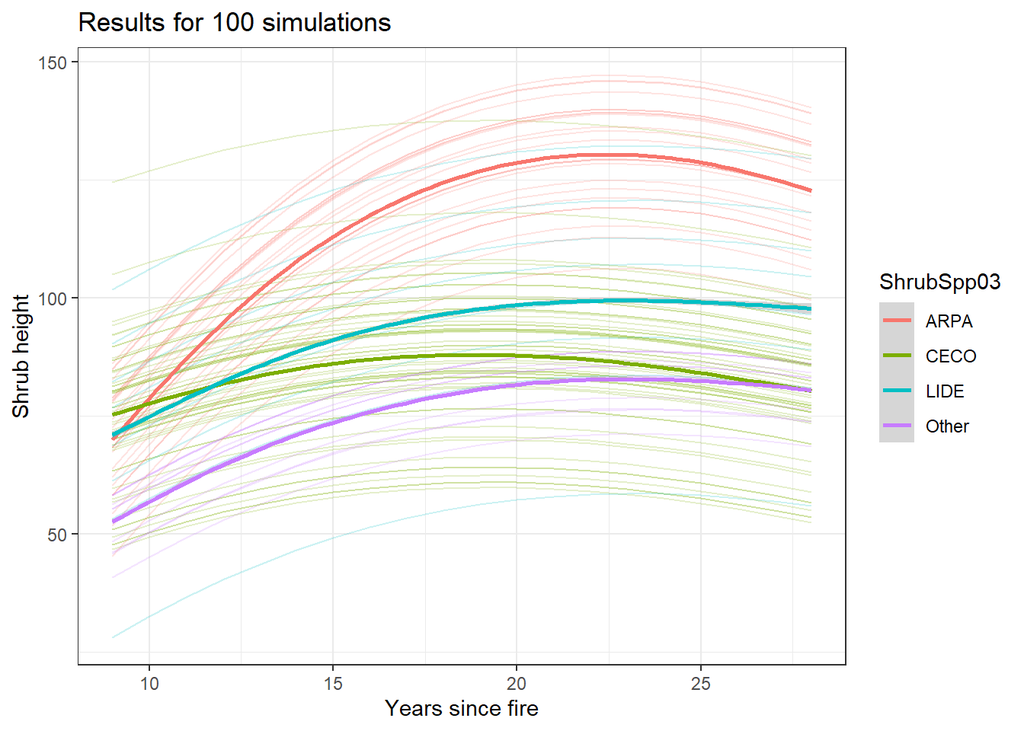

```r
ggplot(dfsimallreps_summary, aes(x = Years, y = mean_shrub_ht, group = ShrubSpp03, col = ShrubSpp03))+
  geom_line(aes(group = Sdlg), alpha = .2)+
  geom_smooth()+
  ggtitle("Results for 100 simulations")+
  xlab("Years since fire")+
  ylab("Shrub height")+
  theme_bw()
```

```r
print(Sys.time() - strt)
```

```
## Time difference of 20.57582 mins
```

## Shrub cover by year

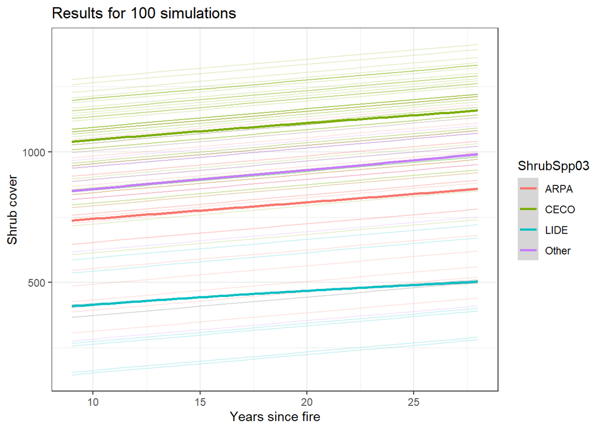

```r
ggplot(dfsimallreps_summary, aes(x = Years, y = mean_shrub_cov, group = ShrubSpp03, col = ShrubSpp03))+
  geom_line(aes(group = Sdlg), alpha = .2)+
  geom_smooth()+
  ggtitle("Results for 100 simulations")+
  xlab("Years since fire")+
  ylab("Shrub cover")+
  theme_bw()
```

```r
print(Sys.time() - strt)
```

```
## Time difference of 20.74125 mins
```

## Seedling height by shrub species and year

```r
dfsimallreps_summary <- dfsimallreps %>%
  ungroup() %>%
  group_by(Species, rep, Years, Ht_cm1, ShrubSpp03) %>%
  mutate(mean_ht = mean(Ht_cm1))
```

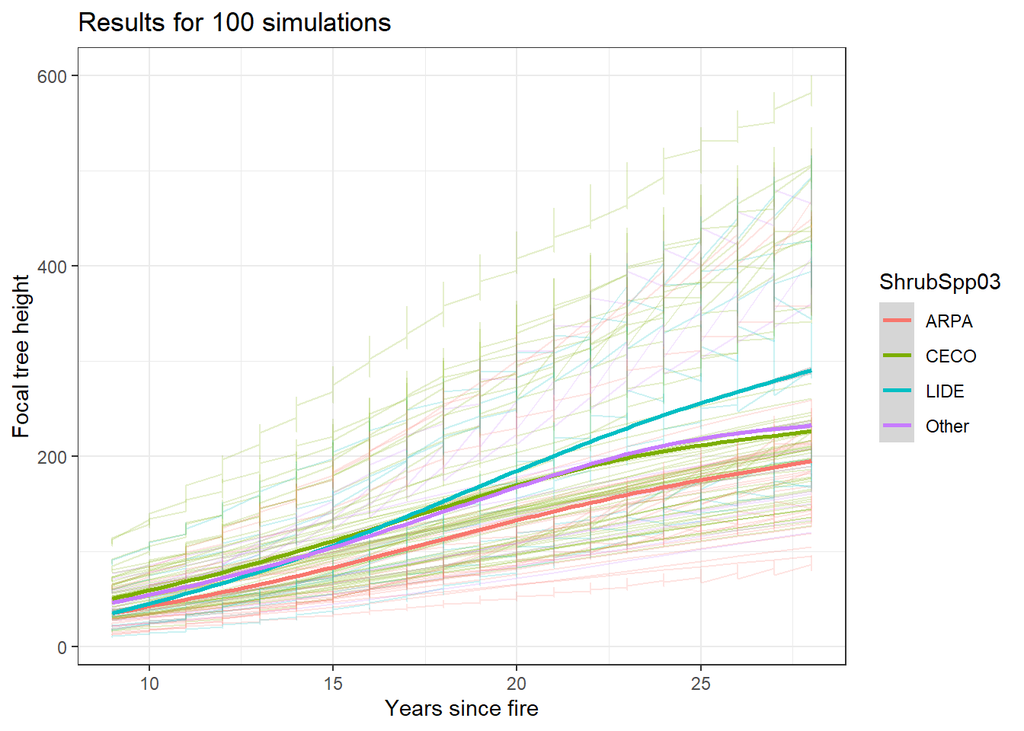

```r
ggplot(dfsimallreps_summary, aes(x = Years, y = Ht_cm1, group = ShrubSpp03, col = ShrubSpp03, symbol = Species))+
  geom_line(aes(group = Sdlg), alpha = .2)+
  geom_smooth()+
  ggtitle("Results for 100 simulations")+
  xlab("Years since fire")+
  ylab("Focal tree height")+
  theme_bw()
```

## Growth by climate year

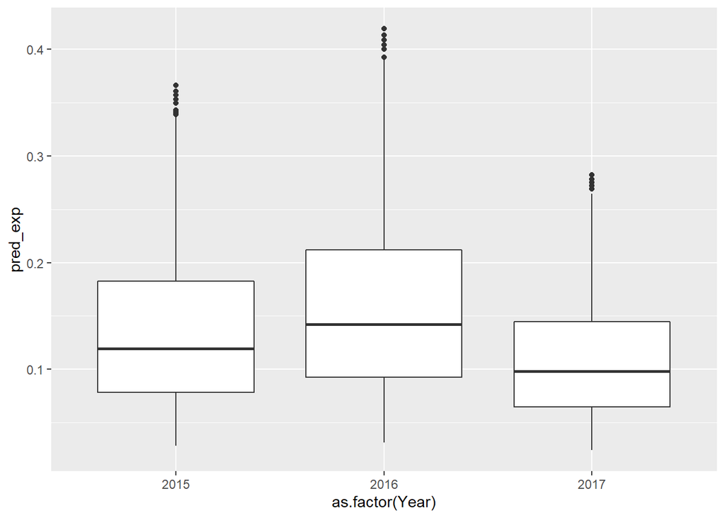

```r
ggplot(dfsimallreps %>% filter(Species == "PIPO"))+
  geom_boxplot(aes(x = as.factor(Year), y = pred_exp))
```

```r
dfsimallreps %>%
  group_by(Year) %>%
  summarize(n(), mean(pred_exp))
```

```
## # A tibble: 3 x 3
##    Year  `n()` `mean(pred_exp)`
##   <dbl>  <int>            <dbl>
## 1  2015 123300            0.109
## 2  2016 137979            0.119
## 3  2017  24522            0.100
```

# Plot how many trees emerge above the shrub canopy each year

```r
dfsimallreps <- dfsimallreps %>%
  mutate(emerged = ifelse(
    Ht_cm1>Ht1.3, 1, 0
  ))
```

```r
summary_emerge <- dfsimallreps %>%
  dplyr::select(Sdlg, Species, ID_withinrep, Ht1.3, Ht_cm1, Years, emerged, rep)  %>%
  group_by(Species, ID_withinrep, rep) %>%
  arrange(Years) %>%
  mutate(cumsum_emerge = cumsum(emerged)) %>%
  mutate(new_emerge = ifelse(cumsum_emerge ==1, 1, 0)) %>%
  ungroup() %>%
  group_by(Years, Species, rep) %>%
  summarize(new_emergents = sum(new_emerge), total= n()) %>%
  ungroup() %>%
  group_by(Species, rep) %>%
  arrange(Years) %>%
  mutate(total_emergents = sum(new_emergents))
```

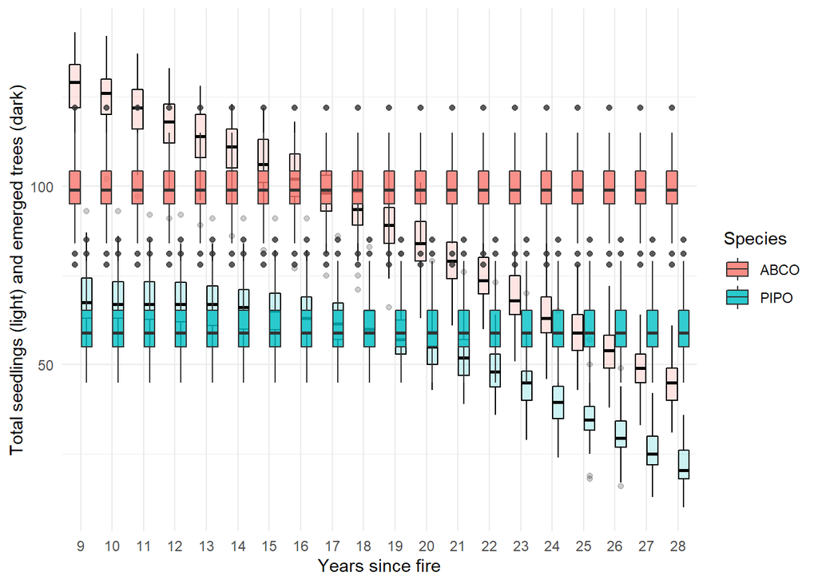

```r
ggplot(summary_emerge)+
  theme_minimal()+
  geom_boxplot(aes(x = as.factor(Years), y = total, fill = Species), col = "black", alpha = .2)+
  geom_boxplot(aes(x = as.factor(Years), y = total_emergents, fill = Species), alpha = .8)+
  ylab("Total seedlings (light) and emerged trees (dark)")+
  xlab("Years since fire")
```

```r
summary_emerge_prop <- summary_emerge %>%
  ungroup() %>%
  group_by(rep, Species) %>%
  mutate(initial_n = max(total)) %>%
  ungroup() %>%
  mutate(prop_total = total/initial_n, prop_emerged = total_emergents/initial_n)

summary_emerge_prop
```

```
## # A tibble: 4,000 x 9
##    Years Species   rep new_emergents total total_emergents initial_n prop_total
##    <dbl> <fct>   <int>         <dbl> <int>           <dbl>     <int>      <dbl>
##  1     9 ABCO        1            22   135             109       135          1
##  2     9 ABCO        2            13   132              98       132          1
##  3     9 ABCO        3            15   124              97       124          1
##  4     9 ABCO        4            10   129              95       129          1
##  5     9 ABCO        5             8   126              95       126          1
##  6     9 ABCO        6            14   117              81       117          1
##  7     9 ABCO        7            16   131             100       131          1
##  8     9 ABCO        8             8   129              96       129          1
##  9     9 ABCO        9            18   128             100       128          1
## 10     9 ABCO       10            12   115              90       115          1
## # ... with 3,990 more rows, and 1 more variable: prop_emerged <dbl>
```

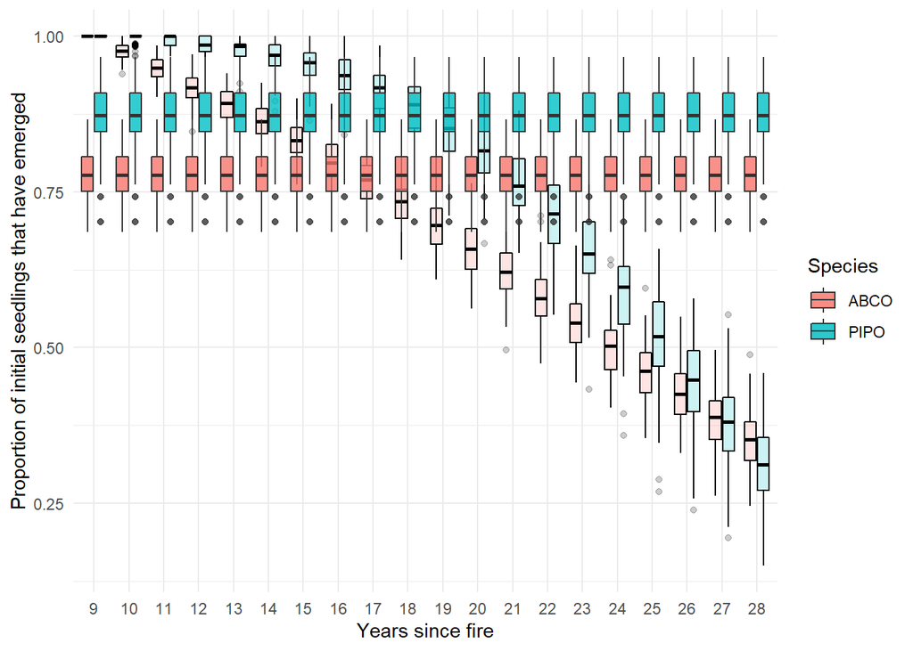

```r
ggplot(summary_emerge_prop)+
  theme_minimal()+
  geom_boxplot(aes(x = as.factor(Years), y = prop_total, fill = Species), col = "black", alpha = .2)+
  geom_boxplot(aes(x = as.factor(Years), y = prop_emerged, fill = Species), alpha = .8)+
  ylab("Proportion of initial seedlings that have emerged")+
  xlab("Years since fire")
```

## Check

```r
dfsimallreps %>%
  filter(Species=="PIPO") %>%
  filter(rep==1 & Years==9) %>%
  select(Sdlg, Ht1.3, Ht_cm1) %>%
  mutate(emerge = ifelse(Ht_cm1>Ht1.3, 1, 9)) %>%
  group_by(emerge) %>%
  count()
```

```
## # A tibble: 2 x 2
## # Groups:   emerge [2]
##   emerge     n
##    <dbl> <int>
## 1      1    13
## 2      9    49
```

## Calculate how many surviving trees are left at last year both emerged and non-emerged

```r
summary_count <- dfsimallreps %>%
  group_by(rep, Species) %>%
  filter(Years == max(Years)) %>%
  summarize(total = n(), emerged = sum(emerged))

summary_count <- pivot_longer(summary_count, cols = c(3,4), names_to = "stat")

summary_count
```

```
## # A tibble: 400 x 4
## # Groups:   rep [100]
##      rep Species stat    value
##    <int> <fct>   <chr>   <dbl>
##  1     1 ABCO    total      51
##  2     1 ABCO    emerged    50
##  3     1 PIPO    total      16
##  4     1 PIPO    emerged    16
##  5     2 ABCO    total      51
##  6     2 ABCO    emerged    49
##  7     2 PIPO    total      19
##  8     2 PIPO    emerged    19
##  9     3 ABCO    total      37
## 10     3 ABCO    emerged    37
## # ... with 390 more rows
```

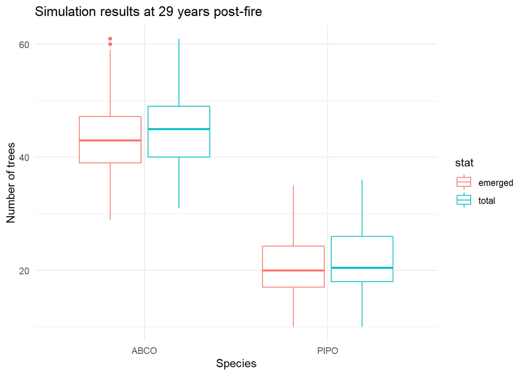

```r
ggplot(summary_count)+
  geom_boxplot(aes(x = Species, y = value, col = stat))+
  theme_minimal()+
  ylab("Number of trees")+
  ggtitle("Simulation results at 29 years post-fire")
```

## Same graph but for proportion of original seedlings

```r
summary_prop <- dfsimallreps %>%
  ungroup() %>%
  group_by(Years, Species, rep) %>%
  mutate(total= n()) %>%
  ungroup() %>%
  group_by(rep, Species) %>%
  mutate(initial_n = max(total))

summary_prop <- summary_prop %>%
  ungroup() %>%
  group_by(rep, initial_n, Species) %>%
  filter(Years== max(Years)) %>%
  summarize(total = n(), emerged = sum(emerged)) %>%
  mutate(prop_total = total/initial_n, prop_emerged = emerged/initial_n)

summary_prop <- pivot_longer(summary_prop, cols = c(4:7), names_to = "stat")
summary_prop
```

```
## # A tibble: 800 x 5
## # Groups:   rep, initial_n [200]
##      rep initial_n Species stat          value
##    <int>     <int> <fct>   <chr>         <dbl>
##  1     1        62 PIPO    total        16
##  2     1        62 PIPO    emerged      16
##  3     1        62 PIPO    prop_total    0.258
##  4     1        62 PIPO    prop_emerged  0.258
##  5     1       135 ABCO    total        51
##  6     1       135 ABCO    emerged      50
##  7     1       135 ABCO    prop_total    0.378
##  8     1       135 ABCO    prop_emerged  0.370
##  9     2        63 PIPO    total        19
## 10     2        63 PIPO    emerged      19
## # ... with 790 more rows
```

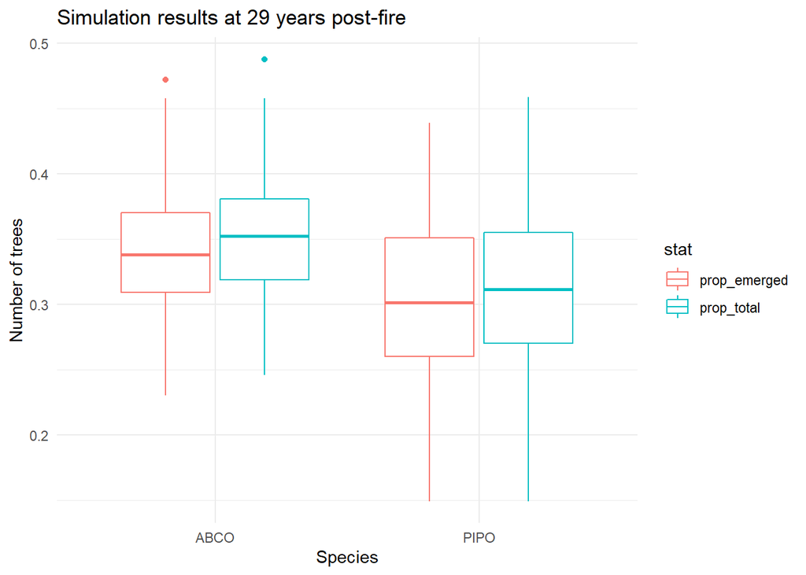

```r
ggplot(summary_prop %>% filter(stat %in% c("prop_total", "prop_emerged")))+
  geom_boxplot(aes(x = Species, y = value, col = stat))+
  theme_minimal()+
  ylab("Number of trees")+
  ggtitle("Simulation results at 29 years post-fire")
```

```r
ggsave(file = "../../results/figures/Simulations/sim_100_emerge_prop_all2015.png", width = 6, height =4, dpi = 400)
```

# Next steps to improve the model

1. Use Kristen’s data or Hugh’s data for initial conditions
2. Improve dispersal kernel based on Kristen/Hugh’s data
3. Include residual surviving trees and their seed dispersal
4. Include seed dispersal of post-fire regen once it reaches reproductive age
5. Add customization of patch size and shape
6. Change sapling growth equations once they emerge from the shrub canopy

For next week:

1. Update display of shrub competition after simulation years
2. apply to King, American River Complex, rest of the fires I measured

Other notes:

1. maybe submit to American Naturalist
2. Global Change Biology - mixing up the years
3. no overstory reproduction for now
4. what does shrub competition mean for new recruitment?